# Homework3

Kathleen Cimino

2/28/2022

1. We will again consider the data set std available through the KMsurv package from your last homework.

The purpose of this study is to identify the factors which are related to time until reinfection. If the factors related to a greater risk of reinfection can be identified, then, interventions could be targeted to those individuals who are at the greatest risk for reinfection.

1. In your previous homework assignment, you were asked to construct a model that examined how number of sexual partners was related to someone’s hazards of reinfection of an std. Your finding was something along the lines of As the number of sexual partners increases by 1, it is expected that the hazards increase by 9% holding all other behavioral risk factors fixed. Do you think it is realistic to assume that going from 0 to 1 sexual partners carries the same increase in hazards of reinfection as going from 23 to 24 sexual partners? Why might someone find it necessary to categorize number of sexual partners into 3 categories: low (0-2), medium (3-5), high(6+)?

It is not realistic to expect that going from 0 to 1 sexual partners carries the same increase in hazards of reinfection as going from 23 to 24 sexual partners. Because this is not realistic, it will likely provide a better understanding of the hazards to group number of sexual partners into categories. This can also help when communicating to people how their number of sexual partners might affect their risk of reinfection.

2. What can be said about how the hazards of someone with a high number of sexual partners compares to the instantaneous hazard rate of someone with a low number of sexual partners?

```r
data(std)
std <- std %>% mutate(
  npartner.cat=ifelse(npartner<=2, 1,ifelse(
    npartner<=5, 2,ifelse(
      npartner>=6, 3, "error"
    )
)))

model1b <- coxph(Surv(time, rinfct) ~ factor(npartner.cat), data=std)
summary(model1b)
```

```
## Call:
## coxph(formula = Surv(time, rinfct) ~ factor(npartner.cat), data = std)
##
##   n= 877, number of events= 347
##
##                          coef exp(coef) se(coef)      z Pr(>|z|)
## factor(npartner.cat)2  0.2972    1.3460   0.2206  1.347    0.178
## factor(npartner.cat)3 -0.9088    0.4030   1.0023 -0.907    0.365
##
##                       exp(coef) exp(-coef) lower .95 upper .95
## factor(npartner.cat)2     1.346     0.7429   0.87348     2.074
## factor(npartner.cat)3     0.403     2.4814   0.05651     2.874
##
## Concordance= 0.509  (se = 0.007 )
## Likelihood ratio test= 2.85  on 2 df,   p=0.2
## Wald test            = 2.67  on 2 df,   p=0.3
## Score (logrank) test = 2.75  on 2 df,   p=0.3
```

2. The following questions consider a data set from a study by Caplehorn et al. (“Methadone Dosage and Retention of Patients in Maintenance Treatment,” Med. J. Aust., 1991). These data comprise the times in days spent by heroin addicts from entry to departure from one of two methadone clinics. There are two further covariates, namely, prison record and methadone dose, believed to affect the survival times. The data set name is addicts.csv. A listing of the variables is given below: • Column 1: Subject ID • Column 2: Clinic (1 or 2) • Column 3: Survival status (0= censored, 1= departed from clinic) • Column 4: Survival time in days • Column 5: Prison record (0 = none, 1 = any) • Column 6: Methadone dose (mg/day)

```r
addicts<-read.csv("https://raw.githubusercontent.com/nazzstat/SurvivalData/master/addicts.csv")
```

1. Graph the KM curves for the two categories of the clinic variable and comment on the extent to which they differ.

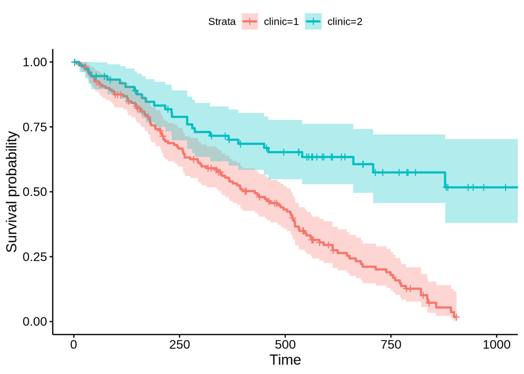

```r
model2a <- survfit(Surv(days,departed)~clinic, data=addicts)
ggsurvplot(model2a, conf.int=TRUE)
```

2. Conduct a test that compares whether the curves vary significantly and state your findings.

```r
survdiff(Surv(days,departed)~clinic, data=addicts, rho=0)
```

```
## Call:
## survdiff(formula = Surv(days, departed) ~ clinic, data = addicts,
##     rho = 0)
##
##            N Observed Expected (O-E)^2/E (O-E)^2/V
## clinic=1 163      122     90.9      10.6      27.9
## clinic=2  75       28     59.1      16.4      27.9
##
##  Chisq= 27.9  on 1 degrees of freedom, p= 1e-07
```

There is a significant difference between the two curves (Chisq= 27.9, p-value < .001).

3. Suppose it was decided a priori to weigh the earlier times more heavily. Conduct an appropriate test to determine whether the survival curves vary. Are you surprised about which test has a smaller p-value? Explain.

```r
survdiff(Surv(days,departed)~clinic, data=addicts, rho=1.5) #Tarone-Ware
```

```
## Call:
## survdiff(formula = Surv(days, departed) ~ clinic, data = addicts,
##     rho = 1.5)
##
##            N Observed Expected (O-E)^2/E (O-E)^2/V
## clinic=1 163     64.6     52.5      2.78      11.9
## clinic=2  75     17.3     29.3      4.98      11.9
##
##  Chisq= 11.9  on 1 degrees of freedom, p= 6e-04
```

4. Compute and evaluate KM curves and the log–rank test for comparing suitably chosen categories of the variable Methadone dose. Explain how you determined the categories for this variable.

```r
addicts <- addicts %>% mutate(
  mdose.cat=ifelse(mdose>median(mdose),"high","low")
                              )
model2d <- survfit(Surv(days,departed)~mdose.cat, data=addicts)
survdiff(Surv(days,departed)~mdose.cat, data=addicts)
```

```
## Call:
## survdiff(formula = Surv(days, departed) ~ mdose.cat, data = addicts)
##
##                  N Observed Expected (O-E)^2/E (O-E)^2/V
## mdose.cat=high  93       48       79      12.2      26.5
## mdose.cat=low  145      102       71      13.6      26.5
##
##  Chisq= 26.5  on 1 degrees of freedom, p= 3e-07
```

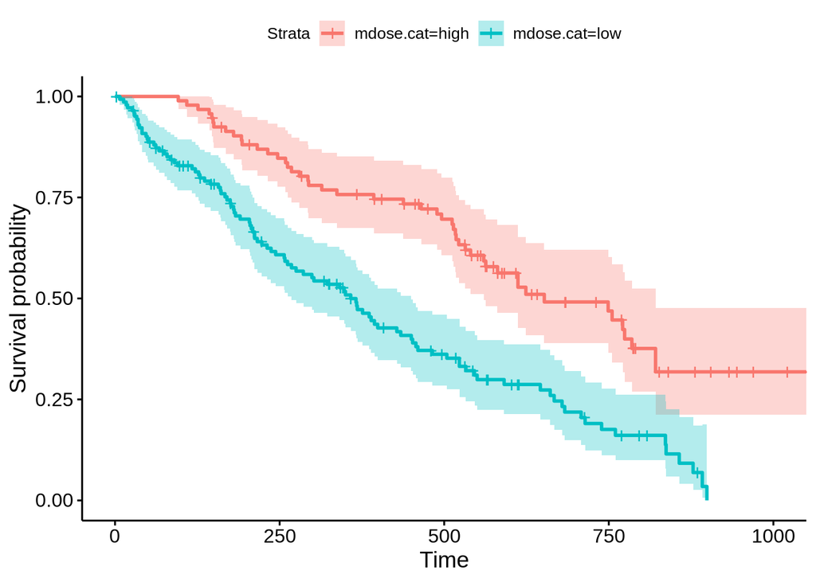

```r
ggsurvplot(model2d, conf.int=TRUE)
```

The methadone dose was categorized into “high” and “low” categories, where anything above the median dose was categorized as “high” as I am not familiar enough with Methadone dosing to create categories based on background knowledge. Visually, the two curves are different, with only a small area of overlap between the 95% CIs. The logrank test affirms that this difference is statistically significant (Chisq=26.5, p-value < .001).

5. Construct an appropriate model and determine whether methodone dose has a significant relationship with length in clinic. (You may use the quantitative version of methadone dose).

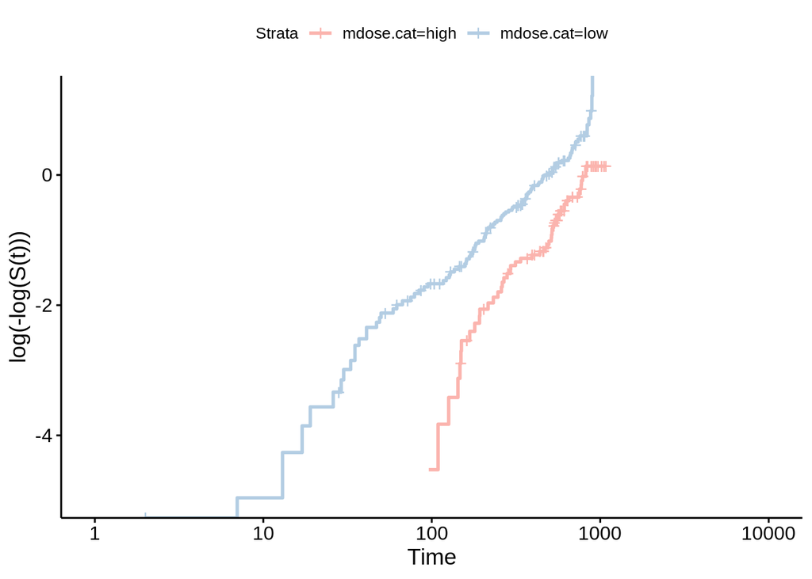

```r
ggsurvplot(model2d, conf.int="FALSE", fun="cloglog", data=addicts, palette="Pastel1")
```

```r
model2e <- coxph(Surv(days, departed)~mdose, data=addicts)
cox.zph(model2e, transform="rank")
```

```
##        chisq df    p
## mdose  0.247  1 0.62
## GLOBAL 0.247  1 0.62
```

```r
summary(model2e)
```

```
## Call:
## coxph(formula = Surv(days, departed) ~ mdose, data = addicts)
##
##   n= 238, number of events= 150
##
##            coef exp(coef)  se(coef)      z Pr(>|z|)
## mdose -0.035903  0.964734  0.005977 -6.007 1.89e-09 ***
## ---
## Signif. codes:  0 '***' 0.001 '**' 0.01 '*' 0.05 '.' 0.1 ' ' 1
##
##       exp(coef) exp(-coef) lower .95 upper .95
## mdose    0.9647      1.037    0.9535    0.9761
##
## Concordance= 0.649  (se = 0.025 )
## Likelihood ratio test= 36.89  on 1 df,   p=1e-09
## Wald test            = 36.08  on 1 df,   p=2e-09
## Score (logrank) test = 36.44  on 1 df,   p=2e-09
```

Visually, there is some potential cause for concern around the 100 mark, but mdose doesn’t appear to seriously violate the PH assumptions, and are no statistically significant violations of assumptions. For every one mg/day increase in Methadone dose, the risk of departing from the clinic decreases by 4%, this relationship is statistically significant ($\hat{HR}$=.965, p-value<.001).

3. The file Rossi.txt contains data from an experimental study of recidivism of 432 male prisoners, who were observed for a year after being released from prison (Rossi et al., 1980). Ultimately we want to understand how different demographic characteristics, work, and financial incentives relate to hazards of re-arrest. • week: week of first arrest after release, or censoring time. • arrest: the event indicator, equal to 1 for those arrested during the period of the study and 0 for those who were not arrested. • fin: a factor, with levels yes if the individual received financial aid after release from prison, and no if he did not; financial aid was a randomly assigned factor manipulated by the researchers. • age: in years at the time of release. • race: a factor with levels black and other. • wexp: a factor with levels yes if the individual had full-time work experience prior to incarceration and no if he did not. • mar: a factor with levels married if the individual was married at the time of release and not married if he was not. • paro: a factor coded yes if the individual was released on parole and no if he was not. • prio: number of prior convictions. • educ: education, a categorical variable coded numerically, with codes 2 (grade 6 or less), 3 (grades 6 through 9), 4 (grades 10 and 11), 5 (grade 12), or 6 (some post-secondary).6 • emp1 − emp52: if individual is employed at week 1, week 2,. . . , week52 after release:

Rossi<-read.csv(“https://raw.githubusercontent.com/nazzstat/SurvivalData/master/Rossi.csv”)

1. What explanatory variables of interest are internally time-dependent, inherently time-dependent, and time independent?

arrest and emp1-emp52 are internally time-dependent. week is inherently time dependent. fin, age, race, wexp, mar, paro, prio, and educ are time independent.

2. Describe how the data would need to be structured in order to understand how employment relates to hazards of re-arrest. You may write out how the data would need to appear for the first two individuals of the data set.

The data would need to have a new row for each change in employment.

| X | week | arrest | fin | age | race | wexp | mar | paro | prior | educ | emp | empweek |
| --- | --- | --- | --- | --- | --- | --- | --- | --- | --- | --- | --- | --- |
| 1 | 20 | 1 | no | 27 | black | no | not married | yes | 3 | 3 | no | 1 |
| 2 | 17 | 1 | no | 18 | black | no | not married | yes | 3 | 8 | no | 1 |
| 2 | 17 | 1 | no | 18 | black | no | not married | yes | 3 | 8 | yes | 10 |
| 2 | 17 | 1 | no | 18 | black | no | not married | yes | 3 | 8 | no | 15 |